# Chapter12_The_connection_between_probability_and_area

Setting up a fancy stylesheet

```python
from IPython.core.display import HTML, Image
css_file = 'style.css'
HTML(open(css_file, 'r').read())
```

Setting up the required python ™ environment

```python
import numpy as np
from scipy.stats import bayes_mvs
from math import factorial
import scikits.bootstrap as bs
import matplotlib.pyplot as plt
import seaborn as sns
from warnings import filterwarnings

%matplotlib inline
filterwarnings('ignore')
```

# The connection between probability and area

No lecture series on statistics and research will be complete without the ubiqutous dice experiement. It is fundemental, though, to understadn the concept of probabilioty, and more importantly, how the graphical representation of simple geometrical surface area relates to probability, otherwise known as the all-powerfull *p-value*.

## Considering the outcomes of the two dice experiment

Imgaine you have two individual, garden-variety die. Both are six sided and each surface is marked with dots (from *1* to *6*). Roll them! What are the possible outcomes when you add the number of dots that land face-up? Let's list them:

- 1 + 1 = 2
- 1 + 2 = 3
- 1 + 3 = 4
- 1 + 4 = 5
- 1 + 5 = 6
- 1 + 6 = 7
- 2 + 1 = 3
- 2 + 2 = 4
- 2 + 3 = 5
- 2 + 4 = 6
- 2 + 5 = 7
- 2 + 6 = 8
- 3 + 1 = 4
- 3 + 2 = 5
- 3 + 3 = 6
- 3 + 4 = 7
- 3 + 5 = 8
- 3 + 6 = 9
- 4 + 1 = 5
- 4 + 2 = 6
- 4 + 3 = 7
- 4 + 4 = 8
- 4 + 5 = 9
- 4 + 6 = 10
- 5 + 1 = 6
- 5 + 2 = 7
- 5 + 3 = 8
- 5 + 4 = 9
- 5 + 5 = 10
- 5 + 6 = 11
- 6 + 1 = 7
- 6 + 2 = 8
- 6 + 3 = 9
- 6 + 4 = 10
- 6 + 5 = 11
- 6 + 6 = 12

That gives us a total of *36* possible outcomes. It included all possibile outcomes! Nothing is left out and nothing else can occur. We say it is mutually exclusive and collectively exhaustive. Throwing two die will have of of these outcomes.  
Now, let's list the possible outcomes as a number of times they can occur:

- 2 can only occur in 1 way (1 + 1)
- 3 can occur in 2 ways (1 + 2 and 2 + 1)
- 4 can occur in 3 ways (1 + 3, 3 + 1, and 2 + 2, etc)
- 5 can occur in 4 ways
- 6 can occur in 5 ways
- 7 can occur in 6 ways
- 8 can occur in 5 ways
- 9 can occur in 4 ways
- 10 can occur in 3 ways
- 11 can occur in 2 ways
- 12 can occur in 1 way

So, out of a possible chocie of *36* outcomes, you are most likely to throw a *7*. In fact, this can occur in *6* out of the *36* possibilities. If *36* is the sum total of possible outcomes, a *7* will occur in *6 / 36*, or *1/6* (*16.67%* or *0.167*) of the time.  
Let's represent the outcomes as a histogram.

```python
dice_outcomes = np.array([2, 3, 4, 5, 6, 7, 3, 4, 5, 6, 7, 8, 4, 5, 6, 7, 8, 9, 5, 6, 7, 8, 9, 10, 6, 7, 8, 9, 10, 11, 7, 8, 9, 10, 11, 12])
```

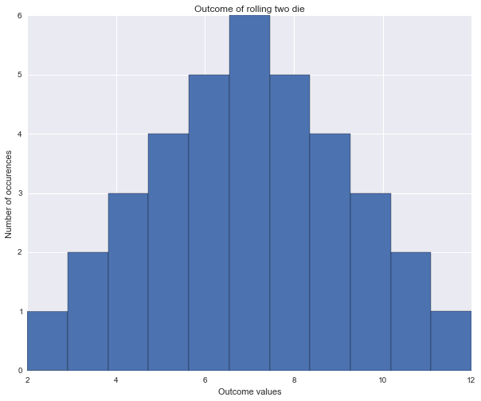

```python
plt.figure(figsize = (10,8))
plt.hist(dice_outcomes, bins = 11)
plt.title('Outcome of rolling two die')
plt.xlabel('Outcome values')
plt.ylabel('Number of occurences')
plt.show();
```

Now, let's represent this as as fractions, i.e. 36 represent *1.0*, the total number of possible outcomes.

```python
x_axis = np.array([2, 3, 4, 5, 6, 7, 8, 9, 10, 11, 12])
y_axis = (1 / 36) * np.array([1, 2, 3, 4, 5, 6, 5, 4, 3, 2, 1])
```

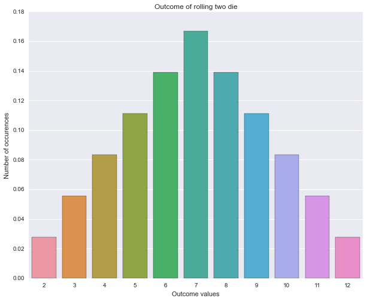

```python
plt.figure(figsize = (10,8))
#sns.distplot(dice_outcomes_probability, bins = 11)
sns.barplot(x_axis, y_axis)
plt.title('Outcome of rolling two die')
plt.xlabel('Outcome values')
plt.ylabel('Number of occurences')
plt.show();
```

## Equating area to probability

Consider the second graph. Now cast your mind way back to school. What was the formula for the area of a rectangle? Right, *height* times *width*. We know that the probability of rolling a *7* is *6 / 36* or *0.167* (that's 16.7%). This *0.167* is the area of the rectangle of *7*. Note, though, we are dealing with dicrete variables here. There is no *7.5*. You can only throw a *6* or a *7*.

This is why we make a distinction between discrete and continuous variables. Discrete variables cannot be subdivided. hence, when represented as a graph (as above), the width is taken as *1* (one).

From the graph above, also note the gaps between the bars. It is common to represent discrete variables with gaps in-between. It immediately signals to your redaers that this graph represents discrete variables.

It is now a simple matter of answering the question: 'What is the *p-value* (probability) of rolling a *2*?'. Well, it's 0.028. Significant indeed!

## Stepping up to continuous variables

By definition, continuous variables can be subdivided again and again. It becomes impossible to use a *width* of *1*. In essence the *width* becomes *0*. This leaves the area or *p-values* as *0*. We can't have that.

Caculus comes to the resque. It can calculate the area under a smooth curve, but only between two points. We can only ask: 'What was the probability of getting a value more than or less than what we found in our research project?'.

Look at the image below. It is a smooth curve (upside-down parabola). With integration we can calculate the area represented in green, stretching between two x-axis values. Fortunatley, no calculus is required. The software does it all for you.

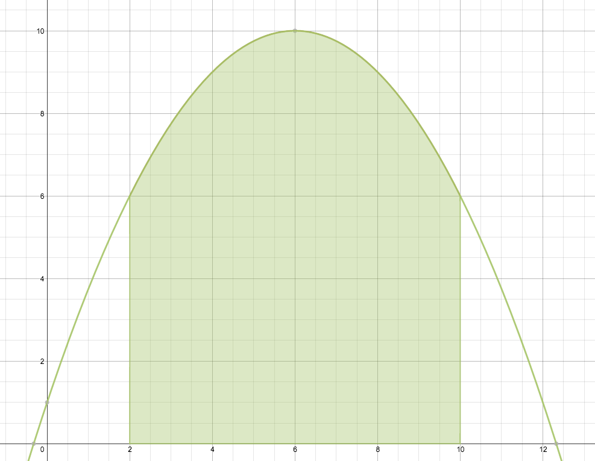

```python
Image(filename = 'calculus.png')
```

In an upcoming lecture we will look at the Central Limit Theorem. With continuous variables, we don't get a blocky histogram as above, in stead we get this smooth bell-shaped curve. It represent a histogram of sorts of the possible outcomes for a study. It is constructed so that the total area under the curve is *1.0*. This is taken care of by a mathematical equation called a probability density function and depends on standard deviations, means, and so on. Each time you calculate a *p-value* a curve such as this is generated. It looks different every time. If we decide that *0.05* indicates statistical significance, we can calculate cut-off points on the x-axis that will represent areas under the curve on *0.025* on either side (indicated in red).

Of note, we can alos throw all our *0.05* eggs in one basket (see the next image on).

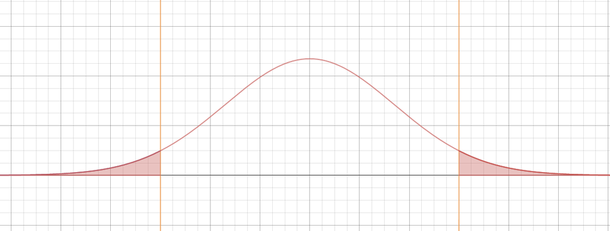

```python
Image(filename = 'AUC.png')
```

In the image below, we have thrown all our egss on the right. Calculating a *p-value* will give us a mark on the x-axis. The software then calculates the area under the curve from this point towards infinity. If it is larger than *0.05* we would say teh finding was not significant. It was not a rare enough occurance. If the area was less than *0.05*, it would have been significant.

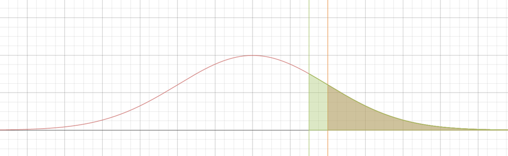

```python
Image(filename = 'p_graph.png')
```

Calculating a *p-value* is then nothing other than calculating geometrical area. The statistical mathematics behind the scenes constrcuts a smooth curve (as above). This curve stretches from negative to psoitive infinity and is done by way of the values found in your study (be they means, or the difference between means of two or more groups).

The one-sided or two-sided nature of these graphs are determined by something we will have a look at later, called the *hypotheses*.